# Bank Financial Project for stock prices Data Analysis and Vizualization

# 1. In this Project we mainly focus on exploratory data analysis of stock prices.

# 2. This project is basically made for to use of the libraries like Numpy, Pandas, matplotlib, seaborn,plotly and cufflinks.

# 3. The data is based on Bank Stocks and see it progressed throughout the financial crisis all the way early to 2016.

```python
# import the needed Libraries
```

```python
from pandas_datareader import data, wb
import numpy as np
import pandas as pd
import datetime
import seaborn as sns
%matplotlib inline
```

# Dataset

# We need to get data using datareader. we will get the stock information for the following banks:

# Bank of America

# City Group

# Goldman Sachs

# JPMorgan Chase

# Morgan Stanley

# Wells Fargo

# We need to figure out how to get the stock data from Jan 1st 2006 to Jan 1st 2016 for each of this banks.

# So, First we need to set each bank to the seprate dataframe, with the variable name for that bank being its ticker symbol. This will involve a few steps:

# 1. Use datetime to start and end datetime objects.

# 2. Figure out the ticker symbol for each bank.

# 3. Figure out how to use datareader to grab info on the stock.

```python
df = pd.read_pickle('all_banks')
```

```python
df
```

| Bank Ticker Stock Info Date | BAC Open | BAC High | BAC Low | BAC Close | BAC Volume | C Open | C High | C Low | C Close | C Volume | ... | MS Open | MS High | MS Low | MS Close | MS Volume | WFC Open | WFC High | WFC Low | WFC Close | WFC Volume |
| --- | --- | --- | --- | --- | --- | --- | --- | --- | --- | --- | --- | --- | --- | --- | --- | --- | --- | --- | --- | --- | --- |
| 2006-01-03 | 46.92 | 47.18 | 46.15 | 47.08 | 16296700 | 490.00 | 493.80 | 481.10 | 492.90 | 1537660 | ... | 57.17 | 58.49 | 56.74 | 58.31 | 5377000 | 31.60 | 31.98 | 31.20 | 31.90 | 11016400 |
| 2006-01-04 | 47.00 | 47.24 | 46.45 | 46.58 | 17757900 | 488.60 | 491.00 | 483.50 | 483.80 | 1871020 | ... | 58.70 | 59.28 | 58.35 | 58.35 | 7977800 | 31.80 | 31.82 | 31.36 | 31.53 | 10871000 |
| 2006-01-05 | 46.58 | 46.83 | 46.32 | 46.64 | 14970900 | 484.40 | 487.80 | 484.00 | 486.20 | 1143160 | ... | 58.55 | 58.59 | 58.02 | 58.51 | 5778000 | 31.50 | 31.56 | 31.31 | 31.50 | 10158000 |
| 2006-01-06 | 46.80 | 46.91 | 46.35 | 46.57 | 12599800 | 488.80 | 489.00 | 482.00 | 486.20 | 1370250 | ... | 58.77 | 58.85 | 58.05 | 58.57 | 6889800 | 31.58 | 31.78 | 31.38 | 31.68 | 8403800 |
| 2006-01-09 | 46.72 | 46.97 | 46.36 | 46.60 | 15620000 | 486.00 | 487.40 | 483.00 | 483.90 | 1680740 | ... | 58.63 | 59.29 | 58.62 | 59.19 | 4144500 | 31.68 | 31.82 | 31.56 | 31.68 | 5619600 |
| 2006-01-10 | 46.40 | 46.51 | 45.88 | 46.21 | 15634800 | 483.00 | 485.50 | 480.80 | 485.40 | 1365960 | ... | 58.85 | 59.22 | 58.58 | 59.22 | 4713600 | 31.55 | 31.68 | 31.44 | 31.65 | 7157800 |
| 2006-01-11 | 46.06 | 46.25 | 45.75 | 46.10 | 14745100 | 495.80 | 495.80 | 485.80 | 489.80 | 1684440 | ... | 59.15 | 59.88 | 58.84 | 59.57 | 5837900 | 31.65 | 31.90 | 31.58 | 31.82 | 8049600 |
| 2006-01-12 | 46.22 | 46.23 | 45.71 | 45.80 | 10546600 | 491.00 | 491.00 | 488.80 | 490.30 | 1230060 | ... | 59.63 | 59.78 | 59.27 | 59.47 | 3817700 | 31.70 | 31.79 | 31.43 | 31.44 | 10763600 |
| 2006-01-13 | 45.83 | 46.00 | 45.68 | 45.80 | 10791300 | 491.00 | 491.90 | 487.30 | 489.20 | 940930 | ... | 59.57 | 59.67 | 59.06 | 59.38 | 3430900 | 31.55 | 31.80 | 31.51 | 31.62 | 6366000 |
| 2006-01-17 | 45.40 | 45.58 | 45.00 | 45.31 | 14606100 | 485.10 | 487.00 | 482.70 | 484.30 | 1237830 | ... | 59.45 | 59.46 | 58.68 | 58.81 | 2624700 | 31.46 | 31.58 | 31.20 | 31.30 | 10690600 |
| 2006-01-18 | 45.32 | 45.65 | 44.92 | 45.18 | 10911300 | 484.30 | 486.70 | 481.10 | 483.80 | 1218910 | ... | 58.55 | 58.90 | 58.05 | 58.58 | 2904300 | 31.30 | 31.84 | 31.30 | 31.67 | 10798000 |
| 2006-01-19 | 45.88 | 45.88 | 44.85 | 45.14 | 14584000 | 485.60 | 485.80 | 477.00 | 479.40 | 1696500 | ... | 58.75 | 59.98 | 58.71 | 59.35 | 3813000 | 31.80 | 31.82 | 31.27 | 31.30 | 8713400 |
| 2006-01-20 | 45.00 | 45.15 | 44.17 | 44.19 | 25164400 | 472.10 | 474.00 | 456.30 | 456.90 | 4781930 | ... | 59.30 | 59.55 | 57.41 | 57.85 | 5446100 | 31.31 | 31.31 | 30.75 | 30.75 | 18175400 |
| 2006-01-23 | 43.50 | 44.39 | 43.49 | 43.96 | 23459900 | 460.00 | 463.80 | 457.00 | 460.00 | 2025500 | ... | 57.70 | 58.69 | 57.70 | 58.48 | 3801000 | 30.76 | 30.97 | 30.75 | 30.80 | 7047400 |
| 2006-01-24 | 44.08 | 44.68 | 44.04 | 44.24 | 13500300 | 462.90 | 463.60 | 459.90 | 460.10 | 2083740 | ... | 58.82 | 59.45 | 58.62 | 58.69 | 3813600 | 30.82 | 30.98 | 30.66 | 30.80 | 8232400 |
| 2006-01-25 | 44.15 | 44.65 | 44.15 | 44.63 | 15132000 | 461.40 | 463.70 | 460.10 | 462.30 | 1591940 | ... | 59.00 | 59.42 | 58.55 | 59.17 | 4011700 | 30.84 | 31.06 | 30.73 | 31.00 | 8580800 |
| 2006-01-26 | 45.00 | 45.16 | 44.67 | 44.90 | 18449500 | 465.50 | 475.50 | 464.50 | 470.10 | 1988600 | ... | 61.11 | 60.50 | 59.49 | 59.97 | 5790400 | 31.24 | 31.50 | 31.18 | 31.28 | 8598000 |
| 2006-01-27 | 44.90 | 45.11 | 44.61 | 44.80 | 12250800 | 470.10 | 473.70 | 466.00 | 468.70 | 1412760 | ... | 60.00 | 61.00 | 59.79 | 60.78 | 3700100 | 31.28 | 31.60 | 31.04 | 31.35 | 7640000 |
| 2006-01-30 | 44.75 | 45.35 | 44.25 | 44.48 | 14816000 | 468.70 | 469.90 | 466.60 | 468.20 | 1057630 | ... | 61.45 | 61.85 | 60.64 | 60.67 | 4246600 | 31.35 | 31.36 | 31.15 | 31.24 | 5756400 |
| 2006-01-31 | 44.65 | 44.73 | 44.12 | 44.23 | 19151000 | 468.30 | 470.50 | 465.50 | 465.80 | 1887280 | ... | 60.50 | 61.91 | 60.49 | 61.45 | 5178400 | 31.12 | 31.30 | 31.10 | 31.18 | 11763400 |
| 2006-02-01 | 44.10 | 44.24 | 43.86 | 43.95 | 15854800 | 465.90 | 467.20 | 461.10 | 463.30 | 1844970 | ... | 61.10 | 61.96 | 60.89 | 61.83 | 3586000 | 30.95 | 30.98 | 30.75 | 30.92 | 8224400 |
| 2006-02-02 | 43.95 | 43.97 | 43.37 | 43.44 | 14745300 | 459.00 | 461.00 | 451.00 | 451.80 | 2325470 | ... | 61.65 | 62.14 | 60.85 | 61.27 | 3469800 | 30.82 | 30.90 | 30.60 | 30.65 | 9831600 |
| 2006-02-03 | 43.30 | 43.55 | 42.75 | 43.09 | 17097100 | 450.70 | 456.10 | 448.10 | 450.60 | 1666510 | ... | 60.60 | 62.15 | 60.36 | 61.44 | 3961600 | 30.42 | 30.72 | 30.31 | 30.52 | 7532400 |
| 2006-02-06 | 43.40 | 43.65 | 43.24 | 43.37 | 12554600 | 452.60 | 456.10 | 450.90 | 451.70 | 1147430 | ... | 61.26 | 61.91 | 61.23 | 61.73 | 2629500 | 30.42 | 30.60 | 30.34 | 30.52 | 7290000 |
| 2006-02-07 | 43.60 | 43.87 | 43.46 | 43.49 | 13917200 | 452.00 | 453.80 | 450.00 | 450.50 | 1207780 | ... | 61.35 | 61.54 | 60.27 | 60.53 | 3811900 | 30.50 | 30.68 | 30.45 | 30.56 | 8097000 |
| 2006-02-08 | 43.55 | 43.72 | 43.34 | 43.67 | 12564600 | 453.30 | 455.30 | 450.70 | 453.60 | 1051370 | ... | 61.15 | 61.36 | 60.80 | 61.27 | 2719000 | 30.50 | 30.72 | 30.40 | 30.66 | 5928000 |
| 2006-02-09 | 43.75 | 44.05 | 43.70 | 43.83 | 13766200 | 455.00 | 461.00 | 454.30 | 457.90 | 1357740 | ... | 61.27 | 61.90 | 61.10 | 61.18 | 2714000 | 30.60 | 30.82 | 30.50 | 30.62 | 7052600 |
| 2006-02-10 | 43.77 | 44.02 | 43.41 | 43.92 | 9039000 | 457.00 | 460.70 | 452.50 | 459.60 | 1272030 | ... | 61.00 | 61.14 | 59.38 | 60.31 | 4483600 | 30.64 | 30.97 | 30.57 | 30.86 | 6501200 |
| 2006-02-13 | 43.70 | 43.96 | 43.30 | 43.70 | 8329500 | 460.60 | 462.30 | 454.10 | 456.80 | 1158300 | ... | 60.20 | 60.58 | 59.39 | 59.81 | 4104900 | 30.78 | 30.88 | 30.60 | 30.82 | 5401400 |
| 2006-02-14 | 43.92 | 44.49 | 43.73 | 44.16 | 17049500 | 457.80 | 462.50 | 457.10 | 461.20 | 1518040 | ... | 59.81 | 60.46 | 59.21 | 60.07 | 3715100 | 30.95 | 31.58 | 30.89 | 31.32 | 8263600 |
| ... | ... | ... | ... | ... | ... | ... | ... | ... | ... | ... | ... | ... | ... | ... | ... | ... | ... | ... | ... | ... | ... |
| 2015-11-18 | 17.43 | 17.87 | 17.43 | 17.84 | 84683912 | 53.85 | 55.02 | 53.76 | 54.98 | 18982232 | ... | 33.69 | 34.31 | 33.61 | 34.25 | 10325561 | 55.06 | 55.77 | 54.96 | 55.67 | 16416736 |
| 2015-11-19 | 17.78 | 17.85 | 17.62 | 17.69 | 51517056 | 54.88 | 55.30 | 54.74 | 55.06 | 11997487 | ... | 34.28 | 34.44 | 33.95 | 34.17 | 7836970 | 55.77 | 56.07 | 55.46 | 55.97 | 12151961 |
| 2015-11-20 | 17.81 | 17.83 | 17.59 | 17.65 | 56108450 | 55.37 | 55.37 | 54.55 | 54.75 | 14880188 | ... | 34.33 | 34.53 | 33.78 | 33.91 | 8623629 | 56.26 | 56.26 | 55.72 | 55.82 | 16259282 |
| 2015-11-23 | 17.62 | 17.73 | 17.46 | 17.47 | 50317909 | 54.67 | 54.84 | 54.15 | 54.28 | 14531482 | ... | 33.92 | 34.14 | 33.57 | 33.64 | 7950577 | 55.90 | 56.04 | 55.56 | 55.60 | 9636883 |
| 2015-11-24 | 17.26 | 17.57 | 17.25 | 17.47 | 57915299 | 53.81 | 54.51 | 53.71 | 54.18 | 12900591 | ... | 33.27 | 33.78 | 33.18 | 33.59 | 7806610 | 55.14 | 55.48 | 54.88 | 55.28 | 14156491 |
| 2015-11-25 | 17.51 | 17.57 | 17.41 | 17.44 | 34939034 | 54.29 | 54.33 | 53.76 | 54.08 | 9859420 | ... | 33.62 | 33.75 | 33.44 | 33.61 | 6209990 | 55.46 | 55.52 | 55.10 | 55.22 | 10034400 |
| 2015-11-27 | 17.46 | 17.50 | 17.33 | 17.48 | 22935528 | 54.06 | 54.37 | 53.72 | 54.21 | 5483332 | ... | 33.63 | 33.92 | 33.48 | 33.78 | 3014557 | 55.34 | 55.47 | 54.98 | 55.39 | 4914008 |
| 2015-11-30 | 17.48 | 17.58 | 17.42 | 17.43 | 59755532 | 54.34 | 54.46 | 53.97 | 54.09 | 13900362 | ... | 33.81 | 34.53 | 33.70 | 34.30 | 17128620 | 55.46 | 55.69 | 55.10 | 55.10 | 15170742 |
| 2015-12-01 | 17.52 | 17.81 | 17.48 | 17.81 | 74130038 | 54.40 | 54.91 | 54.25 | 54.88 | 11854218 | ... | 34.60 | 35.35 | 34.60 | 35.27 | 18590807 | 55.51 | 55.77 | 55.27 | 55.71 | 15520744 |
| 2015-12-02 | 17.88 | 17.89 | 17.55 | 17.62 | 76675759 | 54.99 | 55.02 | 54.03 | 54.14 | 15262881 | ... | 35.36 | 35.40 | 34.72 | 34.89 | 10996449 | 55.80 | 55.80 | 55.00 | 55.08 | 12760806 |
| 2015-12-03 | 17.68 | 17.76 | 17.25 | 17.30 | 95810096 | 54.42 | 54.60 | 53.35 | 53.51 | 19749990 | ... | 35.05 | 35.22 | 34.29 | 34.45 | 15021229 | 55.13 | 55.22 | 54.03 | 54.20 | 15410137 |
| 2015-12-04 | 17.44 | 17.83 | 17.38 | 17.80 | 103021728 | 53.66 | 55.33 | 53.52 | 55.09 | 21464081 | ... | 34.66 | 35.58 | 34.40 | 35.32 | 13205404 | 54.48 | 55.88 | 54.30 | 55.67 | 19647728 |
| 2015-12-07 | 17.79 | 17.80 | 17.44 | 17.54 | 81633309 | 54.77 | 54.88 | 53.91 | 54.40 | 15077326 | ... | 35.28 | 35.31 | 34.42 | 34.68 | 8389228 | 55.45 | 55.56 | 55.02 | 55.42 | 17991639 |
| 2015-12-08 | 17.39 | 17.46 | 17.13 | 17.19 | 84873480 | 53.84 | 54.01 | 53.18 | 53.39 | 14785485 | ... | 34.23 | 34.35 | 33.84 | 34.06 | 10613371 | 54.98 | 55.20 | 54.28 | 54.40 | 19949494 |
| 2015-12-09 | 17.11 | 17.38 | 16.87 | 17.10 | 82418050 | 53.05 | 53.81 | 52.31 | 52.81 | 19903691 | ... | 33.80 | 34.31 | 33.09 | 33.37 | 13211217 | 54.12 | 54.94 | 53.71 | 54.12 | 18499649 |
| 2015-12-10 | 17.15 | 17.41 | 16.96 | 17.20 | 68395011 | 52.89 | 53.24 | 52.17 | 52.65 | 16333817 | ... | 33.50 | 33.90 | 33.28 | 33.42 | 10674487 | 54.25 | 54.98 | 53.88 | 54.34 | 14075334 |
| 2015-12-11 | 16.97 | 17.06 | 16.64 | 16.73 | 91503850 | 51.94 | 52.21 | 50.67 | 51.11 | 24093472 | ... | 32.81 | 33.04 | 31.93 | 32.08 | 16133019 | 53.45 | 53.94 | 52.99 | 53.31 | 17815729 |
| 2015-12-14 | 16.76 | 16.89 | 16.50 | 16.80 | 120589534 | 51.14 | 51.73 | 50.50 | 51.10 | 21540948 | ... | 32.13 | 32.52 | 31.39 | 31.88 | 14942519 | 53.32 | 53.57 | 52.75 | 53.20 | 21977431 |
| 2015-12-15 | 17.02 | 17.49 | 16.99 | 17.42 | 99737154 | 51.85 | 52.80 | 51.85 | 52.52 | 21642329 | ... | 32.64 | 33.08 | 32.56 | 32.84 | 13708783 | 53.83 | 55.12 | 53.81 | 54.91 | 19056701 |
| 2015-12-16 | 17.65 | 17.78 | 17.23 | 17.75 | 171576652 | 53.04 | 54.01 | 52.30 | 53.90 | 26044762 | ... | 33.17 | 33.77 | 32.68 | 33.61 | 13682879 | 55.21 | 56.04 | 54.82 | 55.85 | 21086759 |
| 2015-12-17 | 17.80 | 17.83 | 17.30 | 17.30 | 97265726 | 54.01 | 54.20 | 52.71 | 52.84 | 17179578 | ... | 33.83 | 33.85 | 32.36 | 32.38 | 15959804 | 56.11 | 56.24 | 55.47 | 55.47 | 18800520 |
| 2015-12-18 | 17.19 | 17.26 | 16.76 | 16.76 | 136737824 | 52.46 | 52.68 | 51.16 | 51.21 | 25509621 | ... | 32.13 | 32.25 | 31.25 | 31.29 | 19331713 | 55.00 | 55.15 | 53.79 | 53.79 | 31468584 |
| 2015-12-21 | 16.98 | 17.03 | 16.77 | 16.97 | 65150270 | 51.71 | 51.91 | 51.08 | 51.79 | 16928994 | ... | 31.62 | 31.80 | 31.19 | 31.68 | 10920073 | 54.30 | 54.54 | 53.55 | 54.02 | 12993380 |
| 2015-12-22 | 17.05 | 17.11 | 16.85 | 17.08 | 56173502 | 51.99 | 52.13 | 51.39 | 52.01 | 13241343 | ... | 31.96 | 32.38 | 31.61 | 32.22 | 11468401 | 54.36 | 54.50 | 53.70 | 54.34 | 10318062 |
| 2015-12-23 | 17.16 | 17.34 | 17.10 | 17.34 | 65770672 | 52.30 | 52.64 | 52.08 | 52.63 | 14950224 | ... | 32.47 | 32.73 | 32.28 | 32.60 | 6807062 | 54.60 | 55.06 | 54.46 | 55.04 | 13033579 |
| 2015-12-24 | 17.32 | 17.38 | 17.22 | 17.27 | 29373415 | 52.48 | 52.97 | 52.45 | 52.71 | 4671254 | ... | 32.57 | 32.71 | 32.44 | 32.48 | 2798163 | 54.97 | 55.09 | 54.71 | 54.82 | 4999417 |
| 2015-12-28 | 17.22 | 17.23 | 16.98 | 17.13 | 41777497 | 52.57 | 52.57 | 51.96 | 52.38 | 8761743 | ... | 32.36 | 32.36 | 31.95 | 32.17 | 5420280 | 54.55 | 54.78 | 54.17 | 54.68 | 8288841 |
| 2015-12-29 | 17.25 | 17.35 | 17.16 | 17.28 | 45670376 | 52.76 | 53.22 | 52.74 | 52.98 | 10155134 | ... | 32.44 | 32.70 | 32.32 | 32.55 | 6388244 | 55.11 | 55.35 | 54.99 | 55.29 | 7894876 |
| 2015-12-30 | 17.20 | 17.24 | 17.04 | 17.05 | 35066378 | 52.84 | 52.94 | 52.25 | 52.30 | 8763337 | ... | 32.50 | 32.64 | 32.20 | 32.23 | 5057162 | 55.27 | 55.31 | 54.79 | 54.89 | 8016893 |
| 2015-12-31 | 17.01 | 17.07 | 16.83 | 16.83 | 47152968 | 52.07 | 52.39 | 51.75 | 51.75 | 11281771 | ... | 31.91 | 32.30 | 31.77 | 31.81 | 8154307 | 54.51 | 54.95 | 54.22 | 54.36 | 10929767 |

2517 rows × 30 columns

```python
start = datetime.datetime(2006,1,1)
end = datetime.datetime(2016,1,1)
```

```python
# Bank of America

BAC = data.DataReader("BAC", 'yahoo', start, end)
```

```python
BAC
```

| Date | High | Low | Open | Close | Volume | Adj Close |
| --- | --- | --- | --- | --- | --- | --- |
| 2006-01-03 | 47.180000 | 46.150002 | 46.919998 | 47.080002 | 16296700.0 | 34.596096 |
| 2006-01-04 | 47.240002 | 46.450001 | 47.000000 | 46.580002 | 17757900.0 | 34.228691 |
| 2006-01-05 | 46.830002 | 46.320000 | 46.580002 | 46.639999 | 14970700.0 | 34.272778 |
| 2006-01-06 | 46.910000 | 46.349998 | 46.799999 | 46.570000 | 12599800.0 | 34.221321 |
| 2006-01-09 | 46.970001 | 46.360001 | 46.720001 | 46.599998 | 15619400.0 | 34.243366 |
| 2006-01-10 | 46.509998 | 45.880001 | 46.400002 | 46.209999 | 15634600.0 | 33.956776 |
| 2006-01-11 | 46.250000 | 45.750000 | 46.060001 | 46.099998 | 14742100.0 | 33.875950 |
| 2006-01-12 | 46.230000 | 45.709999 | 46.220001 | 45.799999 | 10546600.0 | 33.655510 |
| 2006-01-13 | 46.000000 | 45.680000 | 45.830002 | 45.799999 | 10791000.0 | 33.655510 |
| 2006-01-17 | 45.580002 | 45.000000 | 45.400002 | 45.310001 | 14605900.0 | 33.295433 |
| 2006-01-18 | 45.650002 | 44.919998 | 45.320000 | 45.259998 | 10867000.0 | 33.258682 |
| 2006-01-19 | 45.880001 | 44.849998 | 45.880001 | 45.139999 | 14584000.0 | 33.170521 |
| 2006-01-20 | 45.150002 | 44.169998 | 45.000000 | 44.189999 | 24950800.0 | 32.472408 |
| 2006-01-23 | 44.389999 | 43.490002 | 43.500000 | 43.959999 | 23459500.0 | 32.303413 |
| 2006-01-24 | 44.680000 | 44.040001 | 44.080002 | 44.240002 | 13500300.0 | 32.509151 |
| 2006-01-25 | 44.650002 | 44.150002 | 44.150002 | 44.630001 | 15132000.0 | 32.795738 |
| 2006-01-26 | 45.160000 | 44.669998 | 45.000000 | 44.900002 | 18449100.0 | 32.994156 |
| 2006-01-27 | 45.110001 | 44.610001 | 44.900002 | 44.799999 | 12250800.0 | 32.920662 |
| 2006-01-30 | 45.349998 | 44.250000 | 44.750000 | 44.480000 | 14812100.0 | 32.685516 |
| 2006-01-31 | 44.730000 | 44.119999 | 44.650002 | 44.230000 | 19151000.0 | 32.501823 |
| 2006-02-01 | 44.240002 | 43.860001 | 44.099998 | 43.950001 | 15854700.0 | 32.296047 |
| 2006-02-02 | 43.970001 | 43.369999 | 43.950001 | 43.439999 | 14745100.0 | 31.921293 |
| 2006-02-03 | 43.549999 | 42.919998 | 43.299999 | 43.090000 | 17097000.0 | 31.664091 |
| 2006-02-06 | 43.650002 | 43.240002 | 43.400002 | 43.369999 | 12554600.0 | 31.869852 |
| 2006-02-07 | 43.869999 | 43.459999 | 43.599998 | 43.490002 | 13914200.0 | 31.958019 |
| 2006-02-08 | 43.720001 | 43.340000 | 43.549999 | 43.669998 | 11101600.0 | 32.090298 |
| 2006-02-09 | 44.049999 | 43.700001 | 43.750000 | 43.830002 | 13766200.0 | 32.207878 |
| 2006-02-10 | 44.020000 | 43.410000 | 43.770000 | 43.919998 | 9038900.0 | 32.274017 |
| 2006-02-13 | 43.959999 | 43.299999 | 43.700001 | 43.700001 | 8329500.0 | 32.112350 |
| 2006-02-14 | 44.490002 | 43.730000 | 43.919998 | 44.160000 | 17049200.0 | 32.450375 |
| ... | ... | ... | ... | ... | ... | ... |
| 2015-11-18 | 17.870001 | 17.430000 | 17.430000 | 17.840000 | 85708300.0 | 16.122965 |
| 2015-11-19 | 17.850000 | 17.620001 | 17.780001 | 17.690001 | 51829700.0 | 15.987406 |
| 2015-11-20 | 17.830000 | 17.590000 | 17.809999 | 17.650000 | 56288300.0 | 15.951259 |
| 2015-11-23 | 17.730000 | 17.459999 | 17.620001 | 17.469999 | 50362900.0 | 15.788581 |
| 2015-11-24 | 17.570000 | 17.250000 | 17.260000 | 17.469999 | 58724200.0 | 15.788581 |
| 2015-11-25 | 17.570000 | 17.410000 | 17.510000 | 17.440001 | 34939000.0 | 15.761465 |
| 2015-11-27 | 17.500000 | 17.330000 | 17.459999 | 17.480000 | 22937500.0 | 15.797613 |
| 2015-11-30 | 17.580000 | 17.420000 | 17.480000 | 17.430000 | 61893700.0 | 15.752430 |
| 2015-12-01 | 17.809999 | 17.480000 | 17.520000 | 17.809999 | 74351800.0 | 16.095861 |
| 2015-12-02 | 17.889999 | 17.549999 | 17.879999 | 17.620001 | 76919000.0 | 15.968972 |
| 2015-12-03 | 17.770000 | 17.250000 | 17.680000 | 17.299999 | 95810100.0 | 15.678960 |
| 2015-12-04 | 17.830000 | 17.379999 | 17.440001 | 17.799999 | 103021700.0 | 16.132109 |
| 2015-12-07 | 17.799999 | 17.440001 | 17.790001 | 17.540001 | 81633300.0 | 15.896472 |
| 2015-12-08 | 17.459999 | 17.129999 | 17.389999 | 17.190001 | 84873500.0 | 15.579268 |
| 2015-12-09 | 17.379999 | 16.870001 | 17.110001 | 17.100000 | 82418100.0 | 15.497697 |
| 2015-12-10 | 17.410000 | 16.959999 | 17.150000 | 17.200001 | 68395000.0 | 15.588333 |
| 2015-12-11 | 17.059999 | 16.639999 | 16.969999 | 16.730000 | 91503900.0 | 15.162370 |
| 2015-12-14 | 16.889999 | 16.500000 | 16.760000 | 16.799999 | 121121200.0 | 15.225810 |
| 2015-12-15 | 17.490000 | 16.990000 | 17.020000 | 17.420000 | 99737200.0 | 15.787718 |
| 2015-12-16 | 17.780001 | 17.230000 | 17.650000 | 17.750000 | 171576700.0 | 16.086796 |
| 2015-12-17 | 17.830000 | 17.299999 | 17.799999 | 17.299999 | 97265700.0 | 15.678960 |
| 2015-12-18 | 17.270000 | 16.760000 | 17.190001 | 16.760000 | 136737800.0 | 15.189559 |
| 2015-12-21 | 17.030001 | 16.770000 | 16.980000 | 16.969999 | 65150300.0 | 15.379878 |
| 2015-12-22 | 17.110001 | 16.850000 | 17.049999 | 17.080000 | 56173500.0 | 15.479576 |
| 2015-12-23 | 17.340000 | 17.100000 | 17.160000 | 17.340000 | 65770700.0 | 15.715212 |
| 2015-12-24 | 17.379999 | 17.219999 | 17.320000 | 17.270000 | 29369400.0 | 15.651771 |
| 2015-12-28 | 17.230000 | 16.980000 | 17.219999 | 17.129999 | 41777500.0 | 15.524892 |
| 2015-12-29 | 17.350000 | 17.160000 | 17.250000 | 17.280001 | 45670400.0 | 15.660836 |
| 2015-12-30 | 17.240000 | 17.040001 | 17.200001 | 17.049999 | 35066400.0 | 15.452384 |
| 2015-12-31 | 17.070000 | 16.830000 | 17.010000 | 16.830000 | 47153000.0 | 15.252998 |

2517 rows × 6 columns

```python
#City Group
C = data.DataReader("C", 'yahoo', start,end)
```

```python
C
```

| Date | High | Low | Open | Close | Volume | Adj Close |
| --- | --- | --- | --- | --- | --- | --- |
| 2006-01-03 | 493.799988 | 481.100006 | 490.000000 | 492.899994 | 1537600.0 | 376.303406 |
| 2006-01-04 | 491.000000 | 483.500000 | 488.600006 | 483.799988 | 1870960.0 | 369.355927 |
| 2006-01-05 | 487.799988 | 484.000000 | 484.399994 | 486.200012 | 1143160.0 | 371.188354 |
| 2006-01-06 | 489.000000 | 482.000000 | 488.799988 | 486.200012 | 1370210.0 | 371.188354 |
| 2006-01-09 | 487.399994 | 483.000000 | 486.000000 | 483.899994 | 1680740.0 | 369.432373 |
| 2006-01-10 | 485.500000 | 480.799988 | 483.000000 | 485.399994 | 1365890.0 | 370.577484 |
| 2006-01-11 | 495.799988 | 485.799988 | 495.799988 | 489.799988 | 1684340.0 | 373.936676 |
| 2006-01-12 | 491.000000 | 488.799988 | 491.000000 | 490.299988 | 1230010.0 | 374.318390 |
| 2006-01-13 | 491.899994 | 487.299988 | 491.000000 | 489.200012 | 940880.0 | 373.478607 |
| 2006-01-17 | 487.000000 | 482.700012 | 485.100006 | 484.299988 | 1237740.0 | 369.737640 |
| 2006-01-18 | 486.700012 | 481.100006 | 484.299988 | 483.600006 | 1215070.0 | 369.203339 |
| 2006-01-19 | 485.799988 | 477.000000 | 485.600006 | 479.399994 | 1696500.0 | 365.996887 |
| 2006-01-20 | 474.000000 | 456.299988 | 472.100006 | 456.899994 | 4777680.0 | 348.819214 |
| 2006-01-23 | 463.799988 | 457.000000 | 460.000000 | 460.000000 | 2024410.0 | 351.186005 |
| 2006-01-24 | 463.600006 | 459.899994 | 462.899994 | 460.100006 | 2083740.0 | 351.262329 |
| 2006-01-25 | 463.700012 | 460.100006 | 461.399994 | 462.299988 | 1591940.0 | 352.941895 |
| 2006-01-26 | 475.500000 | 464.500000 | 465.500000 | 470.100006 | 1988560.0 | 358.896820 |
| 2006-01-27 | 473.700012 | 466.000000 | 470.100006 | 468.700012 | 1412760.0 | 357.827942 |
| 2006-01-30 | 469.899994 | 466.600006 | 468.700012 | 468.200012 | 1057630.0 | 357.446259 |
| 2006-01-31 | 470.500000 | 465.500000 | 468.299988 | 465.799988 | 1887080.0 | 355.613922 |
| 2006-02-01 | 467.200012 | 461.100006 | 465.899994 | 463.299988 | 1845250.0 | 353.705322 |
| 2006-02-02 | 461.000000 | 451.000000 | 459.000000 | 451.799988 | 2325420.0 | 348.612610 |
| 2006-02-03 | 456.100006 | 448.100006 | 450.700012 | 450.600006 | 1663510.0 | 347.686737 |
| 2006-02-06 | 453.200012 | 450.899994 | 452.600006 | 451.700012 | 1147420.0 | 348.535492 |
| 2006-02-07 | 453.799988 | 450.000000 | 450.899994 | 450.500000 | 1207470.0 | 347.609497 |
| 2006-02-08 | 455.299988 | 450.700012 | 453.299988 | 453.600006 | 1051350.0 | 350.001495 |
| 2006-02-09 | 461.000000 | 454.299988 | 455.000000 | 457.899994 | 1357740.0 | 353.319366 |
| 2006-02-10 | 460.700012 | 452.500000 | 457.000000 | 459.600006 | 1272030.0 | 354.631256 |
| 2006-02-13 | 462.299988 | 454.100006 | 460.600006 | 456.799988 | 1158300.0 | 352.470795 |
| 2006-02-14 | 462.500000 | 457.100006 | 457.799988 | 461.200012 | 1518040.0 | 355.865723 |
| ... | ... | ... | ... | ... | ... | ... |
| 2015-11-18 | 55.029999 | 53.759998 | 53.849998 | 54.980000 | 19100300.0 | 48.682915 |
| 2015-11-19 | 55.299999 | 54.740002 | 54.880001 | 55.060001 | 11997500.0 | 48.753757 |
| 2015-11-20 | 55.369999 | 54.549999 | 55.369999 | 54.750000 | 14896000.0 | 48.479263 |
| 2015-11-23 | 54.840000 | 54.150002 | 54.669998 | 54.279999 | 14547100.0 | 48.063087 |
| 2015-11-24 | 54.509998 | 53.709999 | 53.810001 | 54.180000 | 12950900.0 | 47.974537 |
| 2015-11-25 | 54.330002 | 53.759998 | 54.290001 | 54.080002 | 9859400.0 | 47.886002 |
| 2015-11-27 | 54.369999 | 53.720001 | 54.060001 | 54.209999 | 5483300.0 | 48.001106 |
| 2015-11-30 | 54.459999 | 53.970001 | 54.340000 | 54.090000 | 14603100.0 | 47.894859 |
| 2015-12-01 | 54.910000 | 54.250000 | 54.400002 | 54.880001 | 11856000.0 | 48.594372 |
| 2015-12-02 | 55.020000 | 54.029999 | 54.990002 | 54.139999 | 15288800.0 | 47.939117 |
| 2015-12-03 | 54.599998 | 53.349998 | 54.419998 | 53.509998 | 19750000.0 | 47.381287 |
| 2015-12-04 | 55.330002 | 53.520000 | 53.660000 | 55.090000 | 21464100.0 | 48.780315 |
| 2015-12-07 | 54.880001 | 53.910000 | 54.770000 | 54.400002 | 15077300.0 | 48.169346 |
| 2015-12-08 | 54.009998 | 53.180000 | 53.840000 | 53.389999 | 14785500.0 | 47.275028 |
| 2015-12-09 | 53.810001 | 52.310001 | 53.049999 | 52.810001 | 19903700.0 | 46.761452 |
| 2015-12-10 | 53.240002 | 52.169998 | 52.889999 | 52.650002 | 16333800.0 | 46.619774 |
| 2015-12-11 | 52.209999 | 50.669998 | 51.939999 | 51.110001 | 24093500.0 | 45.256153 |
| 2015-12-14 | 51.730000 | 50.500000 | 51.139999 | 51.099998 | 21586800.0 | 45.247303 |
| 2015-12-15 | 52.799999 | 51.849998 | 51.849998 | 52.520000 | 21642300.0 | 46.504669 |
| 2015-12-16 | 54.009998 | 52.299999 | 53.040001 | 53.900002 | 26044800.0 | 47.726612 |
| 2015-12-17 | 54.200001 | 52.709999 | 54.009998 | 52.840000 | 17179600.0 | 46.788025 |
| 2015-12-18 | 52.680000 | 51.160000 | 52.459999 | 51.209999 | 25509600.0 | 45.344711 |
| 2015-12-21 | 51.910000 | 51.080002 | 51.709999 | 51.790001 | 16929000.0 | 45.858276 |
| 2015-12-22 | 52.130001 | 51.389999 | 51.990002 | 52.009998 | 13241300.0 | 46.053082 |
| 2015-12-23 | 52.639999 | 52.080002 | 52.299999 | 52.630001 | 14950200.0 | 46.602066 |
| 2015-12-24 | 52.970001 | 52.450001 | 52.480000 | 52.709999 | 4671200.0 | 46.672905 |
| 2015-12-28 | 52.570000 | 51.959999 | 52.570000 | 52.380001 | 8761700.0 | 46.380703 |
| 2015-12-29 | 53.220001 | 52.740002 | 52.759998 | 52.980000 | 10155100.0 | 46.911987 |
| 2015-12-30 | 52.939999 | 52.250000 | 52.840000 | 52.299999 | 8763300.0 | 46.309872 |
| 2015-12-31 | 52.389999 | 51.750000 | 52.070000 | 51.750000 | 11281800.0 | 45.822861 |

2517 rows × 6 columns

```python
# Goldman Sachs
GS  = data.DataReader("GS", 'yahoo', start,end)
```

```python
GS
```

| Date | High | Low | Open | Close | Volume | Adj Close |
| --- | --- | --- | --- | --- | --- | --- |
| 2006-01-03 | 129.440002 | 124.230003 | 126.699997 | 128.869995 | 6188700.0 | 105.687309 |
| 2006-01-04 | 128.910004 | 126.379997 | 127.349998 | 127.089996 | 4861600.0 | 104.227493 |
| 2006-01-05 | 127.320000 | 125.610001 | 126.000000 | 127.040001 | 3717400.0 | 104.186478 |
| 2006-01-06 | 129.250000 | 127.290001 | 127.290001 | 128.839996 | 4319600.0 | 105.662666 |
| 2006-01-09 | 130.619995 | 128.000000 | 128.500000 | 130.389999 | 4723500.0 | 106.933891 |
| 2006-01-10 | 132.949997 | 130.020004 | 130.050003 | 132.029999 | 5536800.0 | 108.278831 |
| 2006-01-11 | 133.800003 | 131.419998 | 131.449997 | 131.970001 | 4671400.0 | 108.229630 |
| 2006-01-12 | 133.210007 | 131.380005 | 131.399994 | 132.250000 | 3725500.0 | 108.459259 |
| 2006-01-13 | 133.660004 | 131.899994 | 132.020004 | 133.259995 | 2894900.0 | 109.287575 |
| 2006-01-17 | 133.130005 | 130.589996 | 131.000000 | 132.589996 | 3621600.0 | 108.738068 |
| 2006-01-18 | 132.679993 | 131.009995 | 131.059998 | 132.369995 | 4302700.0 | 108.557678 |
| 2006-01-19 | 134.820007 | 132.710007 | 132.720001 | 133.820007 | 5010700.0 | 109.746826 |
| 2006-01-20 | 134.059998 | 131.250000 | 132.850006 | 131.440002 | 5679900.0 | 107.996712 |
| 2006-01-23 | 134.179993 | 131.639999 | 131.639999 | 132.869995 | 3847900.0 | 109.171700 |
| 2006-01-24 | 134.089996 | 132.339996 | 132.630005 | 133.000000 | 3758000.0 | 109.278488 |
| 2006-01-25 | 134.039993 | 132.460007 | 133.649994 | 133.559998 | 3740500.0 | 109.738647 |
| 2006-01-26 | 138.360001 | 133.009995 | 133.009995 | 137.399994 | 4808200.0 | 112.893692 |
| 2006-01-27 | 139.750000 | 137.100006 | 137.929993 | 138.940002 | 3687900.0 | 114.159042 |
| 2006-01-30 | 140.639999 | 138.710007 | 139.550003 | 139.869995 | 3168600.0 | 114.923157 |
| 2006-01-31 | 141.860001 | 138.449997 | 139.729996 | 141.250000 | 4906200.0 | 116.057083 |
| 2006-02-01 | 142.949997 | 140.429993 | 141.399994 | 141.710007 | 3635900.0 | 116.434990 |
| 2006-02-02 | 143.770004 | 141.399994 | 142.270004 | 142.520004 | 3711000.0 | 117.100555 |
| 2006-02-03 | 143.119995 | 140.699997 | 141.550003 | 142.740005 | 4178900.0 | 117.281296 |
| 2006-02-06 | 144.100006 | 141.600006 | 142.610001 | 142.820007 | 3849300.0 | 117.347054 |
| 2006-02-07 | 143.309998 | 139.479996 | 142.350006 | 139.479996 | 5207700.0 | 114.602745 |
| 2006-02-08 | 141.929993 | 139.320007 | 140.100006 | 141.139999 | 4481400.0 | 115.966652 |
| 2006-02-09 | 142.850006 | 140.490005 | 141.139999 | 140.850006 | 3059500.0 | 115.728424 |
| 2006-02-10 | 141.850006 | 137.800003 | 140.669998 | 140.809998 | 4433100.0 | 115.695541 |
| 2006-02-13 | 141.800003 | 139.149994 | 139.649994 | 139.649994 | 2155200.0 | 114.742439 |
| 2006-02-14 | 142.320007 | 138.770004 | 141.199997 | 141.779999 | 3003100.0 | 116.492508 |
| ... | ... | ... | ... | ... | ... | ... |
| 2015-11-18 | 194.050003 | 191.009995 | 191.050003 | 193.660004 | 2509200.0 | 177.125275 |
| 2015-11-19 | 194.210007 | 191.669998 | 193.820007 | 193.029999 | 1835800.0 | 176.549057 |
| 2015-11-20 | 193.490005 | 191.110001 | 193.000000 | 191.470001 | 2932100.0 | 175.122223 |
| 2015-11-23 | 191.490005 | 188.520004 | 191.300003 | 189.190002 | 2671700.0 | 173.036926 |
| 2015-11-24 | 189.800003 | 186.559998 | 188.020004 | 188.669998 | 2679400.0 | 172.561279 |
| 2015-11-25 | 189.770004 | 188.149994 | 188.990005 | 189.149994 | 1495600.0 | 173.000351 |
| 2015-11-27 | 191.190002 | 188.850006 | 189.160004 | 190.470001 | 1092700.0 | 174.207657 |
| 2015-11-30 | 191.080002 | 189.240005 | 190.500000 | 190.020004 | 3415000.0 | 174.391205 |
| 2015-12-01 | 193.149994 | 190.009995 | 191.220001 | 193.070007 | 4140900.0 | 177.190353 |
| 2015-12-02 | 193.839996 | 189.800003 | 193.300003 | 190.259995 | 1817200.0 | 174.611435 |
| 2015-12-03 | 191.649994 | 184.729996 | 190.660004 | 185.199997 | 3599000.0 | 169.967590 |
| 2015-12-04 | 190.619995 | 184.750000 | 185.610001 | 189.990005 | 3517200.0 | 174.363708 |
| 2015-12-07 | 190.119995 | 185.000000 | 190.000000 | 185.490005 | 3499900.0 | 170.233765 |
| 2015-12-08 | 184.470001 | 181.839996 | 183.919998 | 182.919998 | 2663800.0 | 167.875153 |
| 2015-12-09 | 184.850006 | 179.830002 | 182.020004 | 180.710007 | 3907500.0 | 165.846924 |
| 2015-12-10 | 183.929993 | 180.309998 | 180.990005 | 182.110001 | 2212300.0 | 167.131775 |
| 2015-12-11 | 180.149994 | 175.470001 | 179.679993 | 176.559998 | 3750100.0 | 162.038239 |
| 2015-12-14 | 178.630005 | 172.899994 | 176.669998 | 176.399994 | 5102400.0 | 161.891403 |
| 2015-12-15 | 183.279999 | 178.850006 | 178.979996 | 182.009995 | 3398700.0 | 167.039963 |
| 2015-12-16 | 186.880005 | 181.679993 | 184.009995 | 186.210007 | 3191700.0 | 170.894562 |
| 2015-12-17 | 187.889999 | 182.610001 | 186.880005 | 182.610001 | 2807900.0 | 167.590637 |
| 2015-12-18 | 181.899994 | 175.389999 | 181.199997 | 175.490005 | 6740800.0 | 161.056259 |
| 2015-12-21 | 178.149994 | 175.830002 | 177.500000 | 177.750000 | 2472900.0 | 163.130341 |
| 2015-12-22 | 180.690002 | 177.050003 | 178.899994 | 180.050003 | 2312800.0 | 165.241226 |
| 2015-12-23 | 183.000000 | 180.460007 | 180.699997 | 182.949997 | 2367900.0 | 167.902679 |
| 2015-12-24 | 183.169998 | 182.020004 | 182.270004 | 182.470001 | 1107600.0 | 167.462173 |
| 2015-12-28 | 181.929993 | 179.839996 | 181.770004 | 181.619995 | 1723300.0 | 166.682083 |
| 2015-12-29 | 184.179993 | 182.500000 | 182.820007 | 183.529999 | 1848900.0 | 168.434937 |
| 2015-12-30 | 183.529999 | 181.839996 | 183.279999 | 182.009995 | 1514300.0 | 167.039963 |
| 2015-12-31 | 182.889999 | 180.029999 | 181.160004 | 180.229996 | 1773900.0 | 165.406387 |

2517 rows × 6 columns

```python
# JP Morgan
JPM = data.DataReader("JPM", 'yahoo', start,end)
```

```python
JPM
```

| Date | High | Low | Open | Close | Volume | Adj Close |
| --- | --- | --- | --- | --- | --- | --- |
| 2006-01-03 | 40.360001 | 39.299999 | 39.830002 | 40.189999 | 12838600.0 | 26.974699 |
| 2006-01-04 | 40.139999 | 39.419998 | 39.779999 | 39.619999 | 13491500.0 | 26.818987 |
| 2006-01-05 | 39.810001 | 39.500000 | 39.610001 | 39.740002 | 8109400.0 | 26.900234 |
| 2006-01-06 | 40.240002 | 39.549999 | 39.919998 | 40.020000 | 7966900.0 | 27.089762 |
| 2006-01-09 | 40.720001 | 39.880001 | 39.880001 | 40.669998 | 16575200.0 | 27.529747 |
| 2006-01-10 | 40.750000 | 40.070000 | 40.500000 | 40.730000 | 16614800.0 | 27.570374 |
| 2006-01-11 | 40.869999 | 40.610001 | 40.730000 | 40.700001 | 12332300.0 | 27.550074 |
| 2006-01-12 | 40.419998 | 39.900002 | 40.250000 | 39.950001 | 12230000.0 | 27.042387 |
| 2006-01-13 | 40.029999 | 39.650002 | 39.779999 | 39.919998 | 10961200.0 | 27.022076 |
| 2006-01-17 | 39.820000 | 39.410000 | 39.480000 | 39.709999 | 9941100.0 | 26.879927 |
| 2006-01-18 | 39.709999 | 38.950001 | 39.110001 | 39.279999 | 17813100.0 | 26.588852 |
| 2006-01-19 | 39.470001 | 38.799999 | 39.340000 | 39.060001 | 12091800.0 | 26.439939 |
| 2006-01-20 | 38.820000 | 37.880001 | 38.810001 | 38.049999 | 20902400.0 | 25.756266 |
| 2006-01-23 | 38.700001 | 37.970001 | 38.139999 | 38.270000 | 13172300.0 | 25.905180 |
| 2006-01-24 | 38.529999 | 38.090000 | 38.270000 | 38.110001 | 9781500.0 | 25.796881 |
| 2006-01-25 | 38.680000 | 38.060001 | 38.160000 | 38.480000 | 14248700.0 | 26.047340 |
| 2006-01-26 | 39.810001 | 38.709999 | 38.709999 | 39.590000 | 16187900.0 | 26.798698 |
| 2006-01-27 | 40.040001 | 39.169998 | 39.250000 | 39.750000 | 12929400.0 | 26.906992 |
| 2006-01-30 | 39.970001 | 39.419998 | 39.520000 | 39.849998 | 8701700.0 | 26.974691 |
| 2006-01-31 | 40.189999 | 39.740002 | 40.029999 | 39.750000 | 15582100.0 | 26.906992 |
| 2006-02-01 | 40.220001 | 39.669998 | 39.880001 | 39.880001 | 11429800.0 | 26.994999 |
| 2006-02-02 | 40.160000 | 39.590000 | 39.880001 | 39.990002 | 10309100.0 | 27.069462 |
| 2006-02-03 | 40.099998 | 39.400002 | 39.450001 | 39.529999 | 10440700.0 | 26.758081 |
| 2006-02-06 | 39.599998 | 39.310001 | 39.400002 | 39.439999 | 6591800.0 | 26.697157 |
| 2006-02-07 | 39.599998 | 39.049999 | 39.200001 | 39.259998 | 8590500.0 | 26.575315 |
| 2006-02-08 | 39.619999 | 39.250000 | 39.279999 | 39.599998 | 10065200.0 | 26.805464 |
| 2006-02-09 | 40.029999 | 39.439999 | 39.529999 | 39.770000 | 8496300.0 | 26.920542 |
| 2006-02-10 | 39.980000 | 39.290001 | 39.619999 | 39.919998 | 8790500.0 | 27.022076 |
| 2006-02-13 | 40.310001 | 39.610001 | 39.770000 | 39.770000 | 7791600.0 | 26.920542 |
| 2006-02-14 | 40.330002 | 39.650002 | 39.660000 | 40.099998 | 12904100.0 | 27.143917 |
| ... | ... | ... | ... | ... | ... | ... |
| 2015-11-18 | 67.550003 | 66.370003 | 66.480003 | 67.449997 | 12911400.0 | 58.178867 |
| 2015-11-19 | 67.820000 | 67.040001 | 67.580002 | 67.660004 | 12839500.0 | 58.360001 |
| 2015-11-20 | 68.110001 | 67.379997 | 67.989998 | 67.540001 | 11209600.0 | 58.256516 |
| 2015-11-23 | 67.580002 | 66.779999 | 67.309998 | 66.879997 | 11339000.0 | 57.687214 |
| 2015-11-24 | 67.139999 | 66.040001 | 66.169998 | 66.779999 | 10910000.0 | 57.600960 |
| 2015-11-25 | 67.120003 | 66.550003 | 66.930000 | 66.860001 | 7772000.0 | 57.669960 |
| 2015-11-27 | 67.330002 | 66.639999 | 67.000000 | 67.169998 | 4052500.0 | 57.937366 |
| 2015-11-30 | 67.519997 | 66.680000 | 67.279999 | 66.680000 | 15147500.0 | 57.514713 |
| 2015-12-01 | 67.830002 | 66.989998 | 67.339996 | 67.610001 | 12708800.0 | 58.316883 |
| 2015-12-02 | 67.879997 | 66.480003 | 67.830002 | 66.660004 | 13440900.0 | 57.497444 |
| 2015-12-03 | 67.029999 | 65.580002 | 66.830002 | 65.800003 | 14626900.0 | 56.755676 |
| 2015-12-04 | 68.000000 | 66.029999 | 66.099998 | 67.889999 | 17786000.0 | 58.558399 |
| 2015-12-07 | 67.750000 | 66.400002 | 67.660004 | 67.000000 | 11686000.0 | 57.790718 |
| 2015-12-08 | 66.959999 | 65.699997 | 66.250000 | 65.959999 | 13084500.0 | 56.893658 |
| 2015-12-09 | 66.580002 | 65.040001 | 65.610001 | 65.459999 | 16770200.0 | 56.462410 |
| 2015-12-10 | 66.500000 | 65.080002 | 65.540001 | 65.610001 | 12839000.0 | 56.591782 |
| 2015-12-11 | 65.160004 | 63.509998 | 64.800003 | 64.070000 | 17889300.0 | 55.263454 |
| 2015-12-14 | 64.760002 | 63.599998 | 64.230003 | 64.269997 | 17638200.0 | 55.435966 |
| 2015-12-15 | 66.650002 | 65.070000 | 65.070000 | 66.099998 | 18126600.0 | 57.014423 |
| 2015-12-16 | 67.739998 | 65.910004 | 66.910004 | 67.529999 | 21720000.0 | 58.247868 |
| 2015-12-17 | 68.000000 | 66.080002 | 67.900002 | 66.279999 | 18122100.0 | 57.169693 |
| 2015-12-18 | 65.970001 | 64.400002 | 65.970001 | 64.400002 | 23819600.0 | 55.548096 |
| 2015-12-21 | 65.559998 | 64.830002 | 65.019997 | 65.540001 | 18869300.0 | 56.531403 |
| 2015-12-22 | 66.000000 | 64.980003 | 65.919998 | 65.680000 | 12149500.0 | 56.652161 |
| 2015-12-23 | 66.849998 | 66.050003 | 66.120003 | 66.730003 | 12524500.0 | 57.557827 |
| 2015-12-24 | 66.889999 | 66.320000 | 66.620003 | 66.599998 | 4468200.0 | 57.445694 |
| 2015-12-28 | 66.449997 | 65.709999 | 66.290001 | 66.379997 | 6610600.0 | 57.255939 |
| 2015-12-29 | 67.300003 | 66.739998 | 66.839996 | 67.070000 | 9820800.0 | 57.851109 |
| 2015-12-30 | 67.050003 | 66.449997 | 67.040001 | 66.589996 | 7190700.0 | 57.437080 |
| 2015-12-31 | 66.779999 | 66.000000 | 66.190002 | 66.029999 | 14654300.0 | 56.954060 |

2517 rows × 6 columns

```python
# Morgan Stanley
MS = data.DataReader("MS", 'yahoo', start,end)
```

```python
MS
```

| Date | High | Low | Open | Close | Volume | Adj Close |
| --- | --- | --- | --- | --- | --- | --- |
| 2006-01-03 | 58.490002 | 56.740002 | 57.169998 | 58.310001 | 5377000.0 | 36.786667 |
| 2006-01-04 | 59.279999 | 58.349998 | 58.700001 | 58.349998 | 7977800.0 | 36.811905 |
| 2006-01-05 | 58.590000 | 58.020000 | 58.549999 | 58.509998 | 5778000.0 | 36.912865 |
| 2006-01-06 | 58.849998 | 58.049999 | 58.770000 | 58.570000 | 6889800.0 | 36.950710 |
| 2006-01-09 | 59.290001 | 58.619999 | 58.630001 | 59.189999 | 4144500.0 | 37.341850 |
| 2006-01-10 | 59.220001 | 58.580002 | 58.849998 | 59.220001 | 4713600.0 | 37.360771 |
| 2006-01-11 | 59.880001 | 58.840000 | 59.150002 | 59.570000 | 5837900.0 | 37.753712 |
| 2006-01-12 | 59.779999 | 59.270000 | 59.630001 | 59.470001 | 3817700.0 | 37.690361 |
| 2006-01-13 | 59.669998 | 59.060001 | 59.570000 | 59.380001 | 3430900.0 | 37.633316 |
| 2006-01-17 | 59.459999 | 58.680000 | 59.450001 | 58.810001 | 2624700.0 | 37.272053 |
| 2006-01-18 | 58.900002 | 58.049999 | 58.549999 | 58.450001 | 2903000.0 | 37.043888 |
| 2006-01-19 | 59.980000 | 58.709999 | 58.750000 | 59.349998 | 3813000.0 | 37.614288 |
| 2006-01-20 | 59.549999 | 57.410000 | 59.299999 | 57.849998 | 5445900.0 | 36.663620 |
| 2006-01-23 | 58.689999 | 57.700001 | 57.700001 | 58.480000 | 3767000.0 | 37.062904 |
| 2006-01-24 | 59.450001 | 58.619999 | 58.820000 | 58.689999 | 3813600.0 | 37.195988 |
| 2006-01-25 | 59.419998 | 58.549999 | 59.000000 | 59.169998 | 4011700.0 | 37.500198 |
| 2006-01-26 | 60.500000 | 59.490002 | 60.490002 | 59.970001 | 5790400.0 | 38.007229 |
| 2006-01-27 | 61.000000 | 59.790001 | 60.000000 | 60.779999 | 3700100.0 | 38.520565 |
| 2006-01-30 | 61.849998 | 60.639999 | 61.450001 | 60.669998 | 4246600.0 | 38.450867 |
| 2006-01-31 | 61.910000 | 60.490002 | 60.500000 | 61.450001 | 5178400.0 | 38.945213 |
| 2006-02-01 | 61.959999 | 60.889999 | 61.099998 | 61.830002 | 3496000.0 | 39.186028 |
| 2006-02-02 | 62.139999 | 60.849998 | 61.650002 | 61.270000 | 3469800.0 | 38.831131 |
| 2006-02-03 | 62.150002 | 60.360001 | 60.599998 | 61.439999 | 3891600.0 | 38.938873 |
| 2006-02-06 | 61.910000 | 61.230000 | 61.259998 | 61.730000 | 2629500.0 | 39.122654 |
| 2006-02-07 | 61.540001 | 60.270000 | 61.349998 | 60.529999 | 3811300.0 | 38.362125 |
| 2006-02-08 | 61.360001 | 60.799999 | 61.150002 | 61.270000 | 2718000.0 | 38.831131 |
| 2006-02-09 | 61.900002 | 61.099998 | 61.270000 | 61.180000 | 2714000.0 | 38.774097 |
| 2006-02-10 | 61.139999 | 59.410000 | 61.000000 | 60.310001 | 4483600.0 | 38.222706 |
| 2006-02-13 | 60.580002 | 59.389999 | 60.200001 | 59.810001 | 4104900.0 | 37.905819 |
| 2006-02-14 | 60.459999 | 59.209999 | 59.810001 | 60.070000 | 3715100.0 | 38.070610 |
| ... | ... | ... | ... | ... | ... | ... |
| 2015-11-18 | 34.310001 | 33.610001 | 33.689999 | 34.250000 | 10396200.0 | 30.111458 |
| 2015-11-19 | 34.439999 | 33.950001 | 34.279999 | 34.169998 | 8947800.0 | 30.041119 |
| 2015-11-20 | 34.529999 | 33.779999 | 34.330002 | 33.910000 | 8624100.0 | 29.812527 |
| 2015-11-23 | 34.139999 | 33.570000 | 33.919998 | 33.639999 | 7963000.0 | 29.575161 |
| 2015-11-24 | 33.779999 | 33.180000 | 33.270000 | 33.590000 | 7954500.0 | 29.531204 |
| 2015-11-25 | 33.750000 | 33.439999 | 33.619999 | 33.610001 | 6210000.0 | 29.548784 |
| 2015-11-27 | 33.919998 | 33.480000 | 33.630001 | 33.779999 | 3014600.0 | 29.698242 |
| 2015-11-30 | 34.529999 | 33.700001 | 33.810001 | 34.299999 | 17416300.0 | 30.155409 |
| 2015-12-01 | 35.349998 | 34.599998 | 34.599998 | 35.270000 | 18594200.0 | 31.008202 |
| 2015-12-02 | 35.400002 | 34.720001 | 35.360001 | 34.889999 | 10996500.0 | 30.674122 |
| 2015-12-03 | 35.220001 | 34.290001 | 35.049999 | 34.450001 | 15021200.0 | 30.287285 |
| 2015-12-04 | 35.580002 | 34.410000 | 34.660000 | 35.320000 | 13205400.0 | 31.052156 |
| 2015-12-07 | 35.310001 | 34.419998 | 35.279999 | 34.680000 | 8389200.0 | 30.489498 |
| 2015-12-08 | 34.349998 | 33.840000 | 34.230000 | 34.060001 | 10613400.0 | 29.944403 |
| 2015-12-09 | 34.310001 | 33.090000 | 33.799999 | 33.369999 | 13211200.0 | 29.337786 |
| 2015-12-10 | 33.900002 | 33.279999 | 33.500000 | 33.419998 | 10674500.0 | 29.381737 |
| 2015-12-11 | 33.049999 | 31.930000 | 32.810001 | 32.080002 | 16133000.0 | 28.203665 |
| 2015-12-14 | 32.520000 | 31.389999 | 32.130001 | 31.879999 | 14990100.0 | 28.027826 |
| 2015-12-15 | 33.080002 | 32.560001 | 32.639999 | 32.840000 | 13708800.0 | 28.871828 |
| 2015-12-16 | 33.770000 | 32.680000 | 33.169998 | 33.610001 | 13682900.0 | 29.548784 |
| 2015-12-17 | 33.849998 | 32.360001 | 33.830002 | 32.380001 | 15959800.0 | 28.467409 |
| 2015-12-18 | 32.250000 | 31.250000 | 32.130001 | 31.290001 | 19331700.0 | 27.509121 |
| 2015-12-21 | 31.799999 | 31.190001 | 31.620001 | 31.680000 | 10920100.0 | 27.851999 |
| 2015-12-22 | 32.380001 | 31.610001 | 31.959999 | 32.220001 | 11468400.0 | 28.326748 |
| 2015-12-23 | 32.730000 | 32.279999 | 32.470001 | 32.599998 | 6807100.0 | 28.660824 |
| 2015-12-24 | 32.709999 | 32.439999 | 32.570000 | 32.480000 | 2798200.0 | 28.555326 |
| 2015-12-28 | 32.360001 | 31.950001 | 32.360001 | 32.169998 | 5420300.0 | 28.282784 |
| 2015-12-29 | 32.700001 | 32.330002 | 32.439999 | 32.549999 | 6388200.0 | 28.616871 |
| 2015-12-30 | 32.650002 | 32.200001 | 32.500000 | 32.230000 | 5057200.0 | 28.335531 |
| 2015-12-31 | 32.299999 | 31.770000 | 31.910000 | 31.809999 | 8154300.0 | 27.966284 |

2517 rows × 6 columns

```python
# Wells Fargo
WFC = data.DataReader("WFC", 'yahoo', start,end)
```

```python
WFC
```

| Date | High | Low | Open | Close | Volume | Adj Close |
| --- | --- | --- | --- | --- | --- | --- |
| 2006-01-03 | 31.975000 | 31.195000 | 31.600000 | 31.900000 | 11016400.0 | 20.723480 |
| 2006-01-04 | 31.820000 | 31.365000 | 31.799999 | 31.530001 | 10870000.0 | 20.483118 |
| 2006-01-05 | 31.555000 | 31.309999 | 31.500000 | 31.495001 | 10158000.0 | 20.460379 |
| 2006-01-06 | 31.775000 | 31.385000 | 31.580000 | 31.680000 | 8403800.0 | 20.580564 |
| 2006-01-09 | 31.825001 | 31.555000 | 31.674999 | 31.674999 | 5619600.0 | 20.577309 |
| 2006-01-10 | 31.684999 | 31.445000 | 31.549999 | 31.650000 | 7157800.0 | 20.561069 |
| 2006-01-11 | 31.895000 | 31.575001 | 31.650000 | 31.815001 | 8047000.0 | 20.668261 |
| 2006-01-12 | 31.790001 | 31.430000 | 31.705000 | 31.445000 | 10763600.0 | 20.427893 |
| 2006-01-13 | 31.795000 | 31.510000 | 31.549999 | 31.625000 | 6365600.0 | 20.544836 |
| 2006-01-17 | 31.575001 | 31.200001 | 31.459999 | 31.299999 | 10690400.0 | 20.333696 |
| 2006-01-18 | 31.844999 | 31.299999 | 31.305000 | 31.799999 | 10780800.0 | 20.658518 |
| 2006-01-19 | 31.820000 | 31.270000 | 31.805000 | 31.305000 | 8713400.0 | 20.336946 |
| 2006-01-20 | 31.309999 | 30.750000 | 31.309999 | 30.750000 | 18166000.0 | 19.976393 |
| 2006-01-23 | 30.969999 | 30.750000 | 30.754999 | 30.805000 | 7047400.0 | 20.012131 |
| 2006-01-24 | 30.975000 | 30.660000 | 30.825001 | 30.795000 | 8232000.0 | 20.005634 |
| 2006-01-25 | 31.065001 | 30.730000 | 30.834999 | 31.000000 | 8580800.0 | 20.138809 |
| 2006-01-26 | 31.500000 | 31.184999 | 31.240000 | 31.285000 | 8598000.0 | 20.323956 |
| 2006-01-27 | 31.600000 | 31.035000 | 31.285000 | 31.350000 | 7640000.0 | 20.366179 |
| 2006-01-30 | 31.365000 | 31.150000 | 31.350000 | 31.235001 | 5756400.0 | 20.291475 |
| 2006-01-31 | 31.295000 | 31.105000 | 31.125000 | 31.180000 | 11763400.0 | 20.255749 |
| 2006-02-01 | 30.985001 | 30.750000 | 30.950001 | 30.920000 | 8224200.0 | 20.255741 |
| 2006-02-02 | 30.895000 | 30.600000 | 30.825001 | 30.650000 | 9830600.0 | 20.078863 |
| 2006-02-03 | 30.719999 | 30.309999 | 30.424999 | 30.520000 | 7532400.0 | 19.993706 |
| 2006-02-06 | 30.600000 | 30.334999 | 30.424999 | 30.525000 | 7290000.0 | 19.996979 |
| 2006-02-07 | 30.680000 | 30.450001 | 30.500000 | 30.565001 | 8095000.0 | 20.023176 |
| 2006-02-08 | 30.725000 | 30.395000 | 30.500000 | 30.665001 | 5924400.0 | 20.088686 |
| 2006-02-09 | 30.815001 | 30.504999 | 30.605000 | 30.615000 | 7052600.0 | 20.055931 |
| 2006-02-10 | 30.969999 | 30.570000 | 30.635000 | 30.865000 | 6501200.0 | 20.219709 |
| 2006-02-13 | 30.875000 | 30.600000 | 30.775000 | 30.825001 | 5401400.0 | 20.193506 |
| 2006-02-14 | 31.584999 | 30.889999 | 30.950001 | 31.325001 | 8263600.0 | 20.521057 |
| ... | ... | ... | ... | ... | ... | ... |
| 2015-11-18 | 55.770000 | 54.970001 | 55.060001 | 55.669998 | 16612600.0 | 47.099842 |
| 2015-11-19 | 56.070000 | 55.459999 | 55.770000 | 55.970001 | 12167600.0 | 47.353668 |
| 2015-11-20 | 56.259998 | 55.720001 | 56.259998 | 55.820000 | 16264100.0 | 47.226749 |
| 2015-11-23 | 56.040001 | 55.560001 | 55.900002 | 55.599998 | 9638100.0 | 47.040619 |
| 2015-11-24 | 55.480000 | 54.889999 | 55.139999 | 55.279999 | 14156500.0 | 46.769901 |
| 2015-11-25 | 55.520000 | 55.099998 | 55.459999 | 55.220001 | 10034400.0 | 46.719120 |
| 2015-11-27 | 55.470001 | 54.980000 | 55.340000 | 55.389999 | 4914000.0 | 46.862957 |
| 2015-11-30 | 55.689999 | 55.099998 | 55.459999 | 55.099998 | 15998900.0 | 46.617596 |
| 2015-12-01 | 55.770000 | 55.270000 | 55.509998 | 55.709999 | 15543400.0 | 47.133686 |
| 2015-12-02 | 55.799999 | 55.000000 | 55.799999 | 55.080002 | 12779900.0 | 46.600677 |
| 2015-12-03 | 55.220001 | 54.029999 | 55.130001 | 54.200001 | 15410100.0 | 45.856152 |
| 2015-12-04 | 55.880001 | 54.310001 | 54.480000 | 55.669998 | 19647700.0 | 47.099842 |
| 2015-12-07 | 55.560001 | 55.020000 | 55.450001 | 55.419998 | 17991600.0 | 46.888336 |
| 2015-12-08 | 55.209999 | 54.279999 | 54.980000 | 54.400002 | 19949500.0 | 46.025356 |
| 2015-12-09 | 54.939999 | 53.709999 | 54.119999 | 54.119999 | 18499600.0 | 45.788464 |
| 2015-12-10 | 54.990002 | 53.880001 | 54.250000 | 54.340000 | 14075300.0 | 45.974606 |
| 2015-12-11 | 53.939999 | 52.990002 | 53.450001 | 53.310001 | 17815700.0 | 45.103168 |
| 2015-12-14 | 53.570000 | 52.750000 | 53.320000 | 53.200001 | 22055100.0 | 45.010098 |
| 2015-12-15 | 55.119999 | 53.810001 | 53.830002 | 54.910000 | 19056700.0 | 46.456852 |
| 2015-12-16 | 56.040001 | 54.820000 | 55.209999 | 55.849998 | 21086800.0 | 47.252140 |
| 2015-12-17 | 56.240002 | 55.470001 | 56.110001 | 55.470001 | 18800500.0 | 46.930641 |
| 2015-12-18 | 55.150002 | 53.790001 | 55.000000 | 53.790001 | 31468600.0 | 45.509266 |
| 2015-12-21 | 54.540001 | 53.549999 | 54.299999 | 54.020000 | 12993400.0 | 45.703857 |
| 2015-12-22 | 54.500000 | 53.700001 | 54.360001 | 54.340000 | 10318100.0 | 45.974606 |
| 2015-12-23 | 55.060001 | 54.459999 | 54.599998 | 55.040001 | 13033600.0 | 46.566833 |
| 2015-12-24 | 55.090000 | 54.709999 | 54.970001 | 54.820000 | 4999400.0 | 46.380711 |
| 2015-12-28 | 54.779999 | 54.169998 | 54.549999 | 54.680000 | 8288800.0 | 46.262257 |
| 2015-12-29 | 55.349998 | 54.990002 | 55.110001 | 55.290001 | 7894900.0 | 46.778351 |
| 2015-12-30 | 55.310001 | 54.790001 | 55.270000 | 54.889999 | 8016900.0 | 46.439926 |
| 2015-12-31 | 54.950001 | 54.220001 | 54.509998 | 54.360001 | 10929800.0 | 45.991516 |

2517 rows × 6 columns

# Create a list of the ticker symbols (as strings) in alphabetical order. call list as tickers

```python
tickers = ['BAC', 'C', 'GS', 'JPM', 'MS', 'WFC']
```

# Use pd.concat to concatenate the bank dataframes together to a single data frame called bank_stocks. Set the keys argument equal to the tickers list. Also pay attention to what axis you concatenate on.

```python
bank_stocks = pd.concat([BAC,C,GS,JPM,MS,WFC],axis=1,keys=tickers)
```

```python
bank_stocks.head()
```

| Date | BAC High | BAC Low | BAC Open | BAC Close | BAC Volume | BAC Adj Close | C High | C Low | C Open | C Close | ... | MS Open | MS Close | MS Volume | MS Adj Close | WFC High | WFC Low | WFC Open | WFC Close | WFC Volume | WFC Adj Close |
| --- | --- | --- | --- | --- | --- | --- | --- | --- | --- | --- | --- | --- | --- | --- | --- | --- | --- | --- | --- | --- | --- |
| 2006-01-03 | 47.180000 | 46.150002 | 46.919998 | 47.080002 | 16296700.0 | 34.596096 | 493.799988 | 481.100006 | 490.000000 | 492.899994 | ... | 57.169998 | 58.310001 | 5377000.0 | 36.786667 | 31.975000 | 31.195000 | 31.600000 | 31.900000 | 11016400.0 | 20.723480 |
| 2006-01-04 | 47.240002 | 46.450001 | 47.000000 | 46.580002 | 17757900.0 | 34.228691 | 491.000000 | 483.500000 | 488.600006 | 483.799988 | ... | 58.700001 | 58.349998 | 7977800.0 | 36.811905 | 31.820000 | 31.365000 | 31.799999 | 31.530001 | 10870000.0 | 20.483118 |
| 2006-01-05 | 46.830002 | 46.320000 | 46.580002 | 46.639999 | 14970700.0 | 34.272778 | 487.799988 | 484.000000 | 484.399994 | 486.200012 | ... | 58.549999 | 58.509998 | 5778000.0 | 36.912865 | 31.555000 | 31.309999 | 31.500000 | 31.495001 | 10158000.0 | 20.460379 |
| 2006-01-06 | 46.910000 | 46.349998 | 46.799999 | 46.570000 | 12599800.0 | 34.221321 | 489.000000 | 482.000000 | 488.799988 | 486.200012 | ... | 58.770000 | 58.570000 | 6889800.0 | 36.950710 | 31.775000 | 31.385000 | 31.580000 | 31.680000 | 8403800.0 | 20.580564 |
| 2006-01-09 | 46.970001 | 46.360001 | 46.720001 | 46.599998 | 15619400.0 | 34.243366 | 487.399994 | 483.000000 | 486.000000 | 483.899994 | ... | 58.630001 | 59.189999 | 4144500.0 | 37.341850 | 31.825001 | 31.555000 | 31.674999 | 31.674999 | 5619600.0 | 20.577309 |

5 rows × 36 columns

# Set the column name levels:

```python
bank_stocks.columns.names = ['Bank Ticker', 'Stock Info']
```

```python
# Check head of the bank_stocks dataframe.

bank_stocks.head()
```

| Bank Ticker Stock Info Date | BAC High | BAC Low | BAC Open | BAC Close | BAC Volume | BAC Adj Close | C High | C Low | C Open | C Close | ... | MS Open | MS Close | MS Volume | MS Adj Close | WFC High | WFC Low | WFC Open | WFC Close | WFC Volume | WFC Adj Close |
| --- | --- | --- | --- | --- | --- | --- | --- | --- | --- | --- | --- | --- | --- | --- | --- | --- | --- | --- | --- | --- | --- |
| 2006-01-03 | 47.180000 | 46.150002 | 46.919998 | 47.080002 | 16296700.0 | 34.596096 | 493.799988 | 481.100006 | 490.000000 | 492.899994 | ... | 57.169998 | 58.310001 | 5377000.0 | 36.786667 | 31.975000 | 31.195000 | 31.600000 | 31.900000 | 11016400.0 | 20.723480 |
| 2006-01-04 | 47.240002 | 46.450001 | 47.000000 | 46.580002 | 17757900.0 | 34.228691 | 491.000000 | 483.500000 | 488.600006 | 483.799988 | ... | 58.700001 | 58.349998 | 7977800.0 | 36.811905 | 31.820000 | 31.365000 | 31.799999 | 31.530001 | 10870000.0 | 20.483118 |
| 2006-01-05 | 46.830002 | 46.320000 | 46.580002 | 46.639999 | 14970700.0 | 34.272778 | 487.799988 | 484.000000 | 484.399994 | 486.200012 | ... | 58.549999 | 58.509998 | 5778000.0 | 36.912865 | 31.555000 | 31.309999 | 31.500000 | 31.495001 | 10158000.0 | 20.460379 |
| 2006-01-06 | 46.910000 | 46.349998 | 46.799999 | 46.570000 | 12599800.0 | 34.221321 | 489.000000 | 482.000000 | 488.799988 | 486.200012 | ... | 58.770000 | 58.570000 | 6889800.0 | 36.950710 | 31.775000 | 31.385000 | 31.580000 | 31.680000 | 8403800.0 | 20.580564 |
| 2006-01-09 | 46.970001 | 46.360001 | 46.720001 | 46.599998 | 15619400.0 | 34.243366 | 487.399994 | 483.000000 | 486.000000 | 483.899994 | ... | 58.630001 | 59.189999 | 4144500.0 | 37.341850 | 31.825001 | 31.555000 | 31.674999 | 31.674999 | 5619600.0 | 20.577309 |

5 rows × 36 columns

# Check Some Exploratory Data Analysis

# What as the max Close price for each bank's stock throughout the time period?

```python
#for tick in tickers:
    #print(tick,bank_stocks[tick]['Close'].max())

bank_stocks.xs(key='Close', axis=1, level='Stock Info').max()
```

```
Bank Ticker
BAC     54.900002
C      564.099976
GS     247.919998
JPM     70.080002
MS      89.300003
WFC     58.520000
dtype: float64
```

# Create a new empty DataFrame called returns. This dataframe will contain the returns for each bank's stock.

```python
returns = pd.DataFrame()
```

# We can use pandas pct_change() method on the Close column to create a column representing this return value. Create a for loop that goes and for each Bank Stock Ticker creates this returns column and sets it as a column in the returns DataFrame.

```python
for tick in tickers:
    returns[tick+ 'Returns'] = bank_stocks[tick]['Close'].pct_change()
```

```python
returns.head()
```

| Date | BACReturns | CReturns | GSReturns | JPMReturns | MSReturns | WFCReturns |
| --- | --- | --- | --- | --- | --- | --- |
| 2006-01-03 | NaN | NaN | NaN | NaN | NaN | NaN |
| 2006-01-04 | -0.010620 | -0.018462 | -0.013812 | -0.014183 | 0.000686 | -0.011599 |
| 2006-01-05 | 0.001288 | 0.004961 | -0.000393 | 0.003029 | 0.002742 | -0.001110 |
| 2006-01-06 | -0.001501 | 0.000000 | 0.014169 | 0.007046 | 0.001025 | 0.005874 |
| 2006-01-09 | 0.000644 | -0.004731 | 0.012030 | 0.016242 | 0.010586 | -0.000158 |

# Create a Pairplot using seaborn of the return dataframe. What Stocks stands for you?

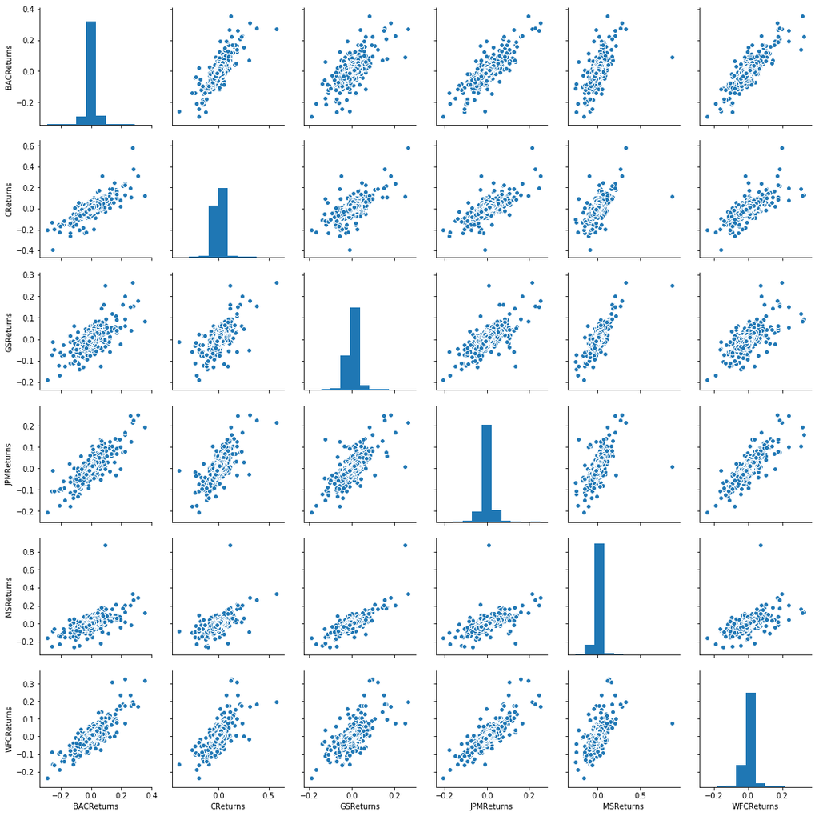

```python
sns.pairplot(returns[1:])
```

# Using this returns DataFrame, figure out on what dates each bank stock had the best and worst single day returns. you should notice that 4 of the share the same day for the worst drop, did anything significant happen that day?

```python
returns.idxmin()
```

```
BACReturns   2009-01-20
CReturns     2009-02-27
GSReturns    2009-01-20
JPMReturns   2009-01-20
MSReturns    2008-10-09
WFCReturns   2009-01-20
dtype: datetime64[ns]
```

```python
returns.idxmax()
```

```
BACReturns   2009-04-09
CReturns     2008-11-24
GSReturns    2008-11-24
JPMReturns   2009-01-21
MSReturns    2008-10-13
WFCReturns   2008-07-16
dtype: datetime64[ns]
```

# To find out standard deviation of the returns, Which stock would you classify as the riskiest over the entire time period? which would you classify as the riskiest for the year 2015?

```python
returns.std()
```

```
BACReturns    0.036647
CReturns      0.038672
GSReturns     0.025390
JPMReturns    0.027667
MSReturns     0.037819
WFCReturns    0.030238
dtype: float64
```

```python
returns.head()
```

| Date | BACReturns | CReturns | GSReturns | JPMReturns | MSReturns | WFCReturns |
| --- | --- | --- | --- | --- | --- | --- |
| 2006-01-03 | NaN | NaN | NaN | NaN | NaN | NaN |
| 2006-01-04 | -0.010620 | -0.018462 | -0.013812 | -0.014183 | 0.000686 | -0.011599 |
| 2006-01-05 | 0.001288 | 0.004961 | -0.000393 | 0.003029 | 0.002742 | -0.001110 |
| 2006-01-06 | -0.001501 | 0.000000 | 0.014169 | 0.007046 | 0.001025 | 0.005874 |
| 2006-01-09 | 0.000644 | -0.004731 | 0.012030 | 0.016242 | 0.010586 | -0.000158 |

```python
returns.loc['2015-01-01': '2015-12-31'].std()
```

```
BACReturns    0.016163
CReturns      0.015289
GSReturns     0.014046
JPMReturns    0.014017
MSReturns     0.016249
WFCReturns    0.012591
dtype: float64
```

# Create a distplot using seaborn of the 2015 returns for Morgan Stanley

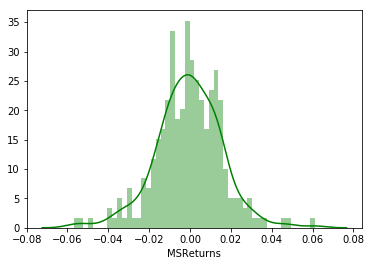

```python
sns.distplot(returns.loc['2015-01-01':'2015-12-31']['MSReturns'],color='green', bins = 50)
```

# Create a distplot using seaborn of the 2008 returns for the CitiGroup

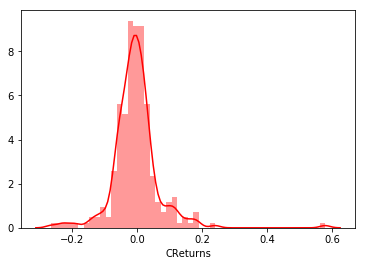

```python
sns.distplot(returns.loc['2008-01-01':'2008-12-31']['CReturns'],color = 'red', bins=50)
```

# Visualization

# This project will focus on visualizations. libraries to try to recreate the described plots below, seaborn, matplotlib, plotly and cufflinks.

```python
# Libraries to import
```

```python
import matplotlib.pyplot as plt
import seaborn as sns
sns.set_style('whitegrid')
%matplotlib inline

import plotly
import cufflinks as cf
cf.go_offline()
```

# Create a line plot showing Close price for each bank for the entire index of time.

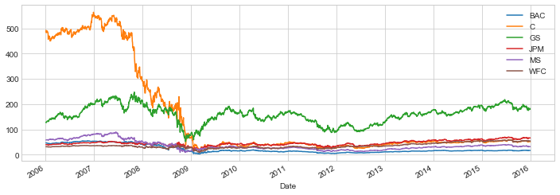

```python
for tick in tickers:
    bank_stocks[tick]['Close'].plot(label=tick,figsize=(12,4))
plt.legend()
```

```python
bank_stocks.xs(key='Close', axis=1,level='Stock Info')
```

| Bank Ticker Date | BAC | C | GS | JPM | MS | WFC |
| --- | --- | --- | --- | --- | --- | --- |
| 2006-01-03 | 47.080002 | 492.899994 | 128.869995 | 40.189999 | 58.310001 | 31.900000 |
| 2006-01-04 | 46.580002 | 483.799988 | 127.089996 | 39.619999 | 58.349998 | 31.530001 |
| 2006-01-05 | 46.639999 | 486.200012 | 127.040001 | 39.740002 | 58.509998 | 31.495001 |
| 2006-01-06 | 46.570000 | 486.200012 | 128.839996 | 40.020000 | 58.570000 | 31.680000 |
| 2006-01-09 | 46.599998 | 483.899994 | 130.389999 | 40.669998 | 59.189999 | 31.674999 |
| 2006-01-10 | 46.209999 | 485.399994 | 132.029999 | 40.730000 | 59.220001 | 31.650000 |
| 2006-01-11 | 46.099998 | 489.799988 | 131.970001 | 40.700001 | 59.570000 | 31.815001 |
| 2006-01-12 | 45.799999 | 490.299988 | 132.250000 | 39.950001 | 59.470001 | 31.445000 |
| 2006-01-13 | 45.799999 | 489.200012 | 133.259995 | 39.919998 | 59.380001 | 31.625000 |
| 2006-01-17 | 45.310001 | 484.299988 | 132.589996 | 39.709999 | 58.810001 | 31.299999 |
| 2006-01-18 | 45.259998 | 483.600006 | 132.369995 | 39.279999 | 58.450001 | 31.799999 |
| 2006-01-19 | 45.139999 | 479.399994 | 133.820007 | 39.060001 | 59.349998 | 31.305000 |
| 2006-01-20 | 44.189999 | 456.899994 | 131.440002 | 38.049999 | 57.849998 | 30.750000 |
| 2006-01-23 | 43.959999 | 460.000000 | 132.869995 | 38.270000 | 58.480000 | 30.805000 |
| 2006-01-24 | 44.240002 | 460.100006 | 133.000000 | 38.110001 | 58.689999 | 30.795000 |
| 2006-01-25 | 44.630001 | 462.299988 | 133.559998 | 38.480000 | 59.169998 | 31.000000 |
| 2006-01-26 | 44.900002 | 470.100006 | 137.399994 | 39.590000 | 59.970001 | 31.285000 |
| 2006-01-27 | 44.799999 | 468.700012 | 138.940002 | 39.750000 | 60.779999 | 31.350000 |
| 2006-01-30 | 44.480000 | 468.200012 | 139.869995 | 39.849998 | 60.669998 | 31.235001 |
| 2006-01-31 | 44.230000 | 465.799988 | 141.250000 | 39.750000 | 61.450001 | 31.180000 |
| 2006-02-01 | 43.950001 | 463.299988 | 141.710007 | 39.880001 | 61.830002 | 30.920000 |
| 2006-02-02 | 43.439999 | 451.799988 | 142.520004 | 39.990002 | 61.270000 | 30.650000 |
| 2006-02-03 | 43.090000 | 450.600006 | 142.740005 | 39.529999 | 61.439999 | 30.520000 |
| 2006-02-06 | 43.369999 | 451.700012 | 142.820007 | 39.439999 | 61.730000 | 30.525000 |
| 2006-02-07 | 43.490002 | 450.500000 | 139.479996 | 39.259998 | 60.529999 | 30.565001 |
| 2006-02-08 | 43.669998 | 453.600006 | 141.139999 | 39.599998 | 61.270000 | 30.665001 |
| 2006-02-09 | 43.830002 | 457.899994 | 140.850006 | 39.770000 | 61.180000 | 30.615000 |
| 2006-02-10 | 43.919998 | 459.600006 | 140.809998 | 39.919998 | 60.310001 | 30.865000 |
| 2006-02-13 | 43.700001 | 456.799988 | 139.649994 | 39.770000 | 59.810001 | 30.825001 |
| 2006-02-14 | 44.160000 | 461.200012 | 141.779999 | 40.099998 | 60.070000 | 31.325001 |
| ... | ... | ... | ... | ... | ... | ... |
| 2015-11-18 | 17.840000 | 54.980000 | 193.660004 | 67.449997 | 34.250000 | 55.669998 |
| 2015-11-19 | 17.690001 | 55.060001 | 193.029999 | 67.660004 | 34.169998 | 55.970001 |
| 2015-11-20 | 17.650000 | 54.750000 | 191.470001 | 67.540001 | 33.910000 | 55.820000 |
| 2015-11-23 | 17.469999 | 54.279999 | 189.190002 | 66.879997 | 33.639999 | 55.599998 |
| 2015-11-24 | 17.469999 | 54.180000 | 188.669998 | 66.779999 | 33.590000 | 55.279999 |
| 2015-11-25 | 17.440001 | 54.080002 | 189.149994 | 66.860001 | 33.610001 | 55.220001 |
| 2015-11-27 | 17.480000 | 54.209999 | 190.470001 | 67.169998 | 33.779999 | 55.389999 |
| 2015-11-30 | 17.430000 | 54.090000 | 190.020004 | 66.680000 | 34.299999 | 55.099998 |
| 2015-12-01 | 17.809999 | 54.880001 | 193.070007 | 67.610001 | 35.270000 | 55.709999 |
| 2015-12-02 | 17.620001 | 54.139999 | 190.259995 | 66.660004 | 34.889999 | 55.080002 |
| 2015-12-03 | 17.299999 | 53.509998 | 185.199997 | 65.800003 | 34.450001 | 54.200001 |
| 2015-12-04 | 17.799999 | 55.090000 | 189.990005 | 67.889999 | 35.320000 | 55.669998 |
| 2015-12-07 | 17.540001 | 54.400002 | 185.490005 | 67.000000 | 34.680000 | 55.419998 |
| 2015-12-08 | 17.190001 | 53.389999 | 182.919998 | 65.959999 | 34.060001 | 54.400002 |
| 2015-12-09 | 17.100000 | 52.810001 | 180.710007 | 65.459999 | 33.369999 | 54.119999 |
| 2015-12-10 | 17.200001 | 52.650002 | 182.110001 | 65.610001 | 33.419998 | 54.340000 |
| 2015-12-11 | 16.730000 | 51.110001 | 176.559998 | 64.070000 | 32.080002 | 53.310001 |
| 2015-12-14 | 16.799999 | 51.099998 | 176.399994 | 64.269997 | 31.879999 | 53.200001 |
| 2015-12-15 | 17.420000 | 52.520000 | 182.009995 | 66.099998 | 32.840000 | 54.910000 |
| 2015-12-16 | 17.750000 | 53.900002 | 186.210007 | 67.529999 | 33.610001 | 55.849998 |
| 2015-12-17 | 17.299999 | 52.840000 | 182.610001 | 66.279999 | 32.380001 | 55.470001 |
| 2015-12-18 | 16.760000 | 51.209999 | 175.490005 | 64.400002 | 31.290001 | 53.790001 |
| 2015-12-21 | 16.969999 | 51.790001 | 177.750000 | 65.540001 | 31.680000 | 54.020000 |
| 2015-12-22 | 17.080000 | 52.009998 | 180.050003 | 65.680000 | 32.220001 | 54.340000 |
| 2015-12-23 | 17.340000 | 52.630001 | 182.949997 | 66.730003 | 32.599998 | 55.040001 |
| 2015-12-24 | 17.270000 | 52.709999 | 182.470001 | 66.599998 | 32.480000 | 54.820000 |
| 2015-12-28 | 17.129999 | 52.380001 | 181.619995 | 66.379997 | 32.169998 | 54.680000 |
| 2015-12-29 | 17.280001 | 52.980000 | 183.529999 | 67.070000 | 32.549999 | 55.290001 |
| 2015-12-30 | 17.049999 | 52.299999 | 182.009995 | 66.589996 | 32.230000 | 54.889999 |
| 2015-12-31 | 16.830000 | 51.750000 | 180.229996 | 66.029999 | 31.809999 | 54.360001 |

2517 rows × 6 columns

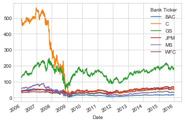

```python
# Instead of for loop we can do it using cross section with one line

bank_stocks.xs(key='Close', axis=1,level='Stock Info').plot()
```

```python
# Finally using plotly to use the same line but in the end to call .iplot()

bank_stocks.xs(key='Close', axis=1,level='Stock Info').iplot()
```

[interactive chart not shown]

# Moving Averages

# Lets analyze the moving averages for these stocks in the year 2008

# Plot the rolling 30 days average agaianst the close price for Bank's of Americas stocks for the year 2008.

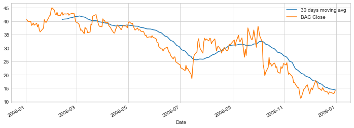

```python
plt.figure(figsize = (12,4))
BAC['Close'].ix['2008-01-01':'2009-01-01'].rolling(window=30).mean().plot(label='30 days moving avg')
BAC['Close'].ix['2008-01-01':'2009-01-01'].plot(label= 'BAC Close')
plt.legend()
```

# Create a heatmap of the correlation between the stocks Close price.

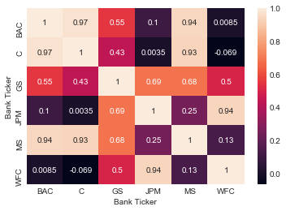

```python
sns.heatmap(bank_stocks.xs(key='Close',axis=1, level='Stock Info').corr(),annot=True)
```

# Use Seaborn's clustermap to cluster the correlations together:

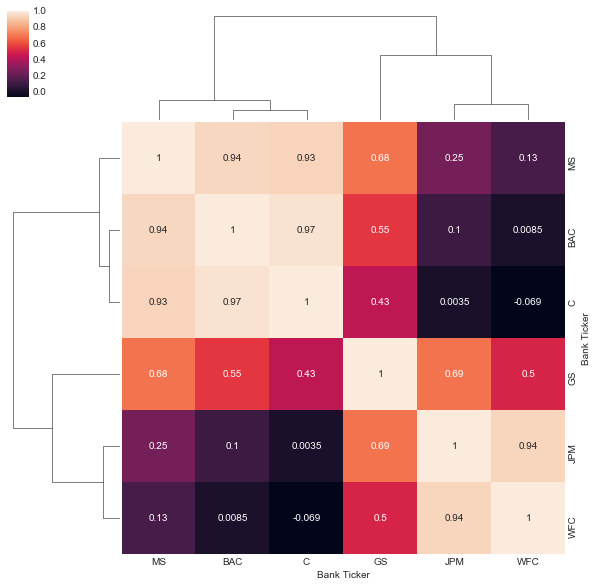

```python
sns.clustermap(bank_stocks.xs(key='Close',axis=1, level='Stock Info').corr(),annot=True)
```

# In this part of the project we are going to create we will rely on the cufflinks to library to create some Technical Analysis plots.

```python
close_corr = bank_stocks.xs(key='Close',axis=1, level='Stock Info').corr()
```

```python
close_corr
```

| Bank Ticker | BAC | C | GS | JPM | MS | WFC |
| --- | --- | --- | --- | --- | --- | --- |
| BAC | 1.000000 | 0.971516 | 0.550898 | 0.103874 | 0.944218 | 0.008542 |
| C | 0.971516 | 1.000000 | 0.434123 | 0.003515 | 0.933609 | -0.068536 |
| GS | 0.550898 | 0.434123 | 1.000000 | 0.685286 | 0.683792 | 0.499897 |
| JPM | 0.103874 | 0.003515 | 0.685286 | 1.000000 | 0.250427 | 0.940269 |
| MS | 0.944218 | 0.933609 | 0.683792 | 0.250427 | 1.000000 | 0.131835 |
| WFC | 0.008542 | -0.068536 | 0.499897 | 0.940269 | 0.131835 | 1.000000 |

```python
close_corr.iplot(kind='heatmap',colorscale='rdylbu')
```

[interactive chart not shown]

# Use .iplot(kind='candle') to create a candle plot of Bank's of America's stock from Jan 1st 2015 to 1st Jan 2016.

```python
bac15 = BAC[['Open','High', 'Low', 'Close']].ix['2015-01-01':'2016-01-01']
bac15.iplot(kind = 'candle')
```

[interactive chart not shown]

# Use .ta_plot(kind='sme') to create a simple moving Averages plot of Morgan Stanley for the year 2015.

```python
MS['Close'].ix['2015-01-01':'2016-01-01'].ta_plot(study='sma', periods= [13,21,55])
```

[interactive chart not shown]